# Reproducible reports with Rmarkdown

Susy Echeverría-Londoño and Drew Kerkhoff

`This document is a work in progress, please give us feedback`

# 1 Reproducible documents

## 1.1 Before we start

[figure not shown]

## 1.2 How does it work?

The `rmarkdown` R package uses and interacts with other packages and programs to create a final document. For example, `knitr` converts the Rmd file into a markdown (.md) file, which is a common format for several websites (including the lectures and guides in this course). `knitr` runs chunks and inline R code and includes the output to a markdown document. `rmarkdown` then calls the `pandoc` program to convert the markdown into different formats. Note that to create a PDF, you need to install [Latex](https://www.latex-project.org/get/). The `bookdown` R package is necessary to number figures, tables and also it can be used to generate books, such as [R for Data Science](http://r4ds.had.co.nz/)

*Source: [A guide to reproducible code in Ecology and Evolution by the BES](https://www.britishecologicalsociety.org/wp-content/uploads/2017/12/guide-to-reproducible-code.pdf)*

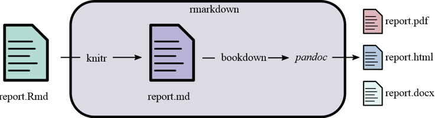

## 1.3 Main parts of an R Markdown file

### 1.3.1 The YAML Header

Included at the top of the R Markdown script, the YAML header enclosed by `----` defines the title, author, date of the document and most importantly the file type you want to output (html, pdf, md, word).

```
---
title: "Example"
author: "YOUR NAME HERE"
date: "01/30/2017"
output: html_document
---
```

You can also alter the appearance and style of your document with different arguments. For example, `toc: true` will include a table of content. Click [Here](https://rmarkdown.rstudio.com/html_document_format.html) to see other arguments.

```
---
title: "Example"
author: "YOUR NAME HERE"
date: "01/30/2017"
output:
  html_document:
  toc: true
---
```

### 1.3.2 Markdown Basic syntax

[R Markdown Cheat sheet](https://www.rstudio.com/wp-content/uploads/2015/02/rmarkdown-cheatsheet.pdf)

```
# Header 1
## Header 2
### Header 3

*Italics*
**Bold**
`inline code`
[link](https://rmarkdown.rstudio.com/)

* Bullet Lists
  + Subitems
```

- Markdown Quick Reference `Help`-> `Markdown Quick Reference`
- R Markdown reference guide `Help`->`Cheatsheets`-> `R Markdown Cheat Sheet` or `R Markdown Reference Guide`

### 1.3.3 Code Chunks

To run R code inside an R Markdown

- The keyboard shortcut Cmd/Ctrl + Alt + I
- Or “Insert” button icon in the toolbar

````
```{r}
msg<-"Hello world"
msg
```
````

```r
msg<-"Hello world"
msg
```

```
## [1] "Hello world"
```

### 1.3.4 Chunks options

To modify how they run and how they appear in the document

**Show only the output**

````
```{r echo=FALSE}
msg<-"Hello world"
msg
```
````

```
## [1] "Hello world"
```

**Run code but does not display code or ouput**

````
```{r include=FALSE}
msg<-"Hello world"
msg
```
````

**Print code but does not run it**

````
```{r eval=FALSE}
msg<-"Hello world"
msg
```
````

```r
msg<-"Hello world"
msg
```

**Do not display messages or warnings**

````
```{r message=FALSE,warning=FALSE}
library(tidyverse)
library(knitr)
```
````

```r
library(tidyverse)
library(knitr)
```

**Naming chunks**

````
```{r hello_world, eval=FALSE}
msg<-"Hello world"
msg
```
````

```r
msg<-"Hello world"
msg
```

### 1.3.5 Inline Code

To incorporate R outputs into the text

The class of the object msg is `` `r class(msg)` `` and it has `` `r length(msg)` `` elements

The class of the object msg is character and it has 1 elements

### 1.3.6 Inserting plots

By default

````
```{r plot1}

data(iris)

ggplot(iris, aes(x = Species, y = Sepal.Width)) + geom_boxplot()

```
````

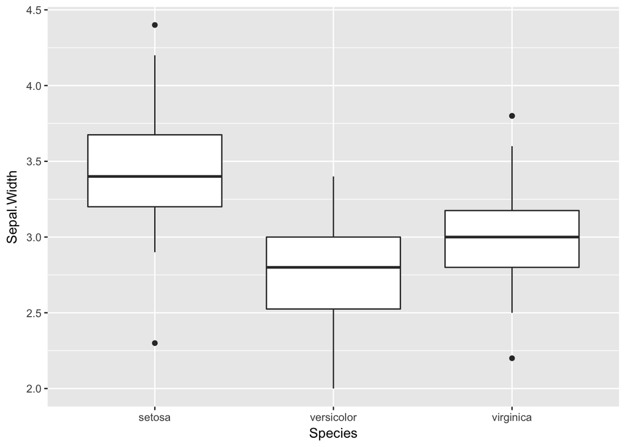

```r
data(iris)

ggplot(iris, aes(x = Species, y = Sepal.Width)) + geom_boxplot()
```

Setting figure dimensions

[output not shown]

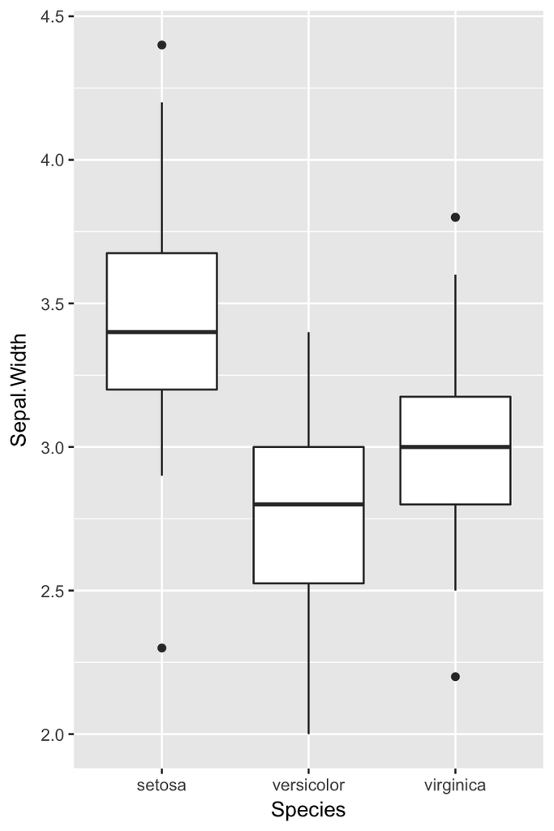

```r
data(iris)

ggplot(iris, aes(x = Species, y = Sepal.Width)) + geom_boxplot()
```

You can include the argument `dev="svg"` to render your plot as a vector format `.svg` instead of the default format `.png`

### 1.3.7 Tables

By default

````
```{r }

head(iris)

```
````

```r
head(iris)
```

```
##   Sepal.Length Sepal.Width Petal.Length Petal.Width Species
## 1          5.1         3.5          1.4         0.2  setosa
## 2          4.9         3.0          1.4         0.2  setosa
## 3          4.7         3.2          1.3         0.2  setosa
## 4          4.6         3.1          1.5         0.2  setosa
## 5          5.0         3.6          1.4         0.2  setosa
## 6          5.4         3.9          1.7         0.4  setosa
```

A bit messy right? For a more pleasing table, we can use the function `kable` from the R package `knitr`

[output not shown]

```r
kable(head(iris))
```

| Sepal.Length | Sepal.Width | Petal.Length | Petal.Width | Species |
| --- | --- | --- | --- | --- |
| 5.1 | 3.5 | 1.4 | 0.2 | setosa |
| 4.9 | 3.0 | 1.4 | 0.2 | setosa |
| 4.7 | 3.2 | 1.3 | 0.2 | setosa |
| 4.6 | 3.1 | 1.5 | 0.2 | setosa |
| 5.0 | 3.6 | 1.4 | 0.2 | setosa |
| 5.4 | 3.9 | 1.7 | 0.4 | setosa |

Or you can direclty create table in markdown syntax

```
| Species| Var1  | Var2   |
|:------ |:-----:|-------:|
| A      | 20    | 0.65   |
| B      | 20    | 0.95   |
| C      | 20    | 0.15   |
```

| Species | Var1 | Var2 |
| --- | --- | --- |
| A | 20 | 0.65 |
| B | 20 | 0.95 |
| C | 20 | 0.15 |

# 2 Reproducible slide presentations

1. Open a new R markdown file `*.Rmd`, `File` -> `New file` -> `R markdown` -> `Presentation`
- Enter a title and author(s).
- Choose ‘Default Output Format’ as HTML (ioslides) (for now)
2. Save the Rmd file
3. knit the document (Windows and Linux, Ctrl+Shift+K; Mac, Command+Shift+K)
4. Open the html in a browser

## 2.1 Display Modes

When you open the html in a browser, use the following character keyboard shortcuts to enable alternate display modes:

- `f` enable fullscreen mode
- `w` toggle widescreen mode
- `o` enable overview mode
- `h` enable code highlight mode

## 2.2 The YAML Header

```
---
title: "Example"
author: "YOUR NAME HERE"
date: "01/30/2017"
output: ioslides_presentation
---
```

By default the argument `echo=FALSE`. Check the setup at the beginning of the document.

````
```{r}

knitr::opts_chunk$set(echo = FALSE)

```
````

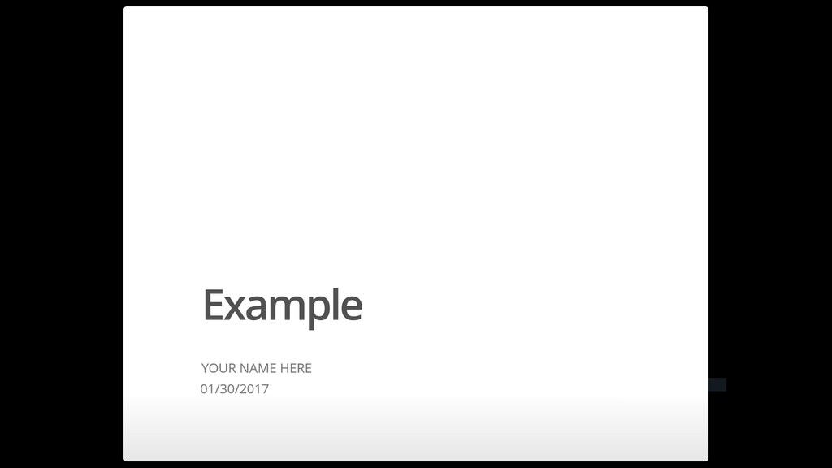

## 2.3 Markdown Basic syntax

```
## Markdown Basic syntax


*Italics*

**Bold**

`inline code`

[link](https://rmarkdown.rstudio.com/)

- Bullet 1
- Bullet 2
- Bullet 3
```

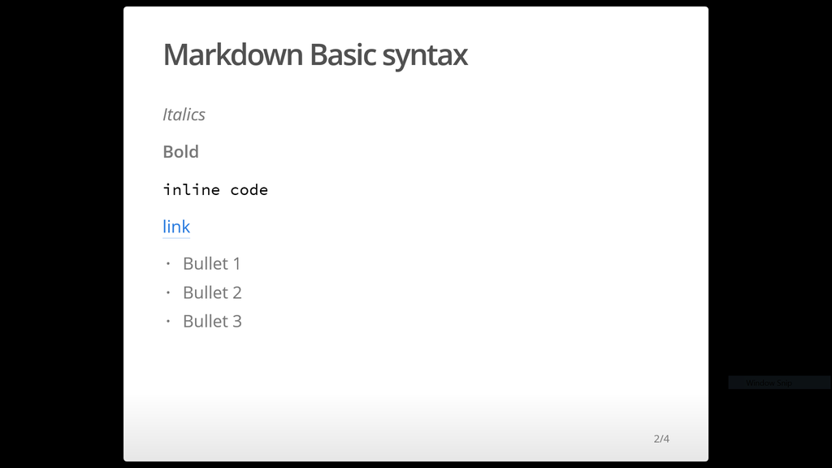

## 2.4 Plots

```
## Slide with R Output
```

````
```{r echo=TRUE, fig.height=4}

data(iris)

ggplot(iris, aes(x = Species, y = Sepal.Width)) + geom_boxplot()

```
````

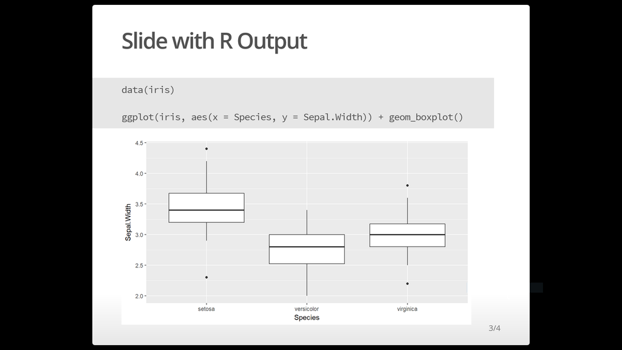

## 2.5 Tables

```
## Tables
```

````
```{r table}

kable(head(iris))

```
````

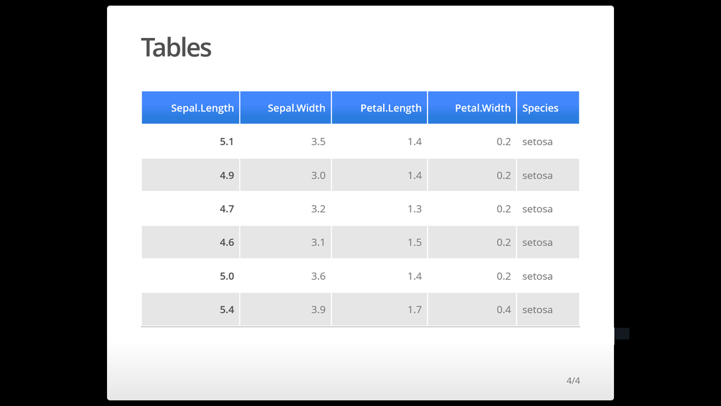

**You can see additional ioslides arguments and options in the following link https://rmarkdown.rstudio.com/ioslides_presentation_format.html**